# Graphics in R

## Short Course on Statistical Programming in R

April 5, 2017

Eric Dunford

### Overview

`R` has powerful graphics libraries that that are flexible, easy to customize, and capable of compelling visualization of different data types.

Today, we'll explore

- the ins-and-outs `base` graphics in `R`
- a powerful graphics package `ggplot2`
- explore generating descriptive maps using `shapefiles`.

## Base Graphics

### Base Graphics

“Base graphics” are the graphics functionality that comes with `R` right when you turn it on. Though basic in construct and design, these functions can produce compelling graphical presentations when customized. As we'll see, the base plotting functions are extremely flexible.

There are a wealth of base graphics functions in `R`, and we'll just cover but a few. Note that there are **many arguments** in each of these functions that do different things. Thus, it is often useful to look at the **documentation of the function**.

```r
?hist()
```

### Loading Shapefiles into R

When loading in shapefiles, we will reference the **.shp** file type. We will use the function `shapefile()` from the package `raster` to do this.

```r
require(raster)
shape <- shapefile("~/nigeria.shp")
```

This file behaves much like a data frame (and thus we can manipulate it as such).

The key feature is that shapefiles contain the specific features of the geographic representation of a specific unit, which can be plotted.

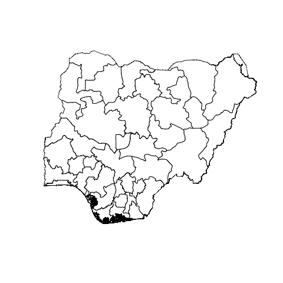

```r
plot(shape)
```

### Applied Example 3

As shapefiles are more nuanced than some of the materials we've been dealing with, we are going to switch back to a script to review this material. Go ahead and open `maps.R` in an R Studio session.

Here we will practice

- loading in and plotting shapefiles
- merging data onto shapefiles
- layering ploygons and mapping points onto each
- Converting location names to lon-lat locations using the Google API.